# Lab 1c. Species Distribution Modeling - Decision Trees

2022-01-11

# 1 Learning Objectives

- explore Supervised Classification for categorical values
  - this is considered a Classification, while Supervised Classification for continuous values is called a Regression
- use Decision Trees as a Classification technique to classify categorical species presence and absence data
  - specifically, use Recursive Partitioning and Random Forest techniques

# 2 Set Up

- load packages
- set options
- select `ggplot` graph theme
- establish directory and file paths for the data

```r
if (!require(librarian)){
  install.packages("librarian")
  library(librarian)
}

librarian::shelf(
  caret,       # m: modeling framework
  dplyr, ggplot2 ,here, readr,
  pdp,         # X: partial dependence plots
  rpart,       # m: recursive partition modeling
  rpart.plot,  # m: recursive partition plotting
  rsample,     # d: split train/test data
  skimr,       # d: skim summarize data table
  vip)         # X: variable importance

options(
  scipen = 999,
  readr.show_col_types = F)
set.seed(42)

ggplot2::theme_set(ggplot2::theme_light())

dir_data    <- here("data")
pts_env_csv <- file.path(dir_data, "pts_env.csv")
```

# 3 Decision Trees

- read in *Necturus maculosus* data
- clean the data
  - remove unnecessary columns
  - change the presence/absence data to a factor
  - drop rows with NA values
- summarize the data using `skim()`

```r
pts_env <- read_csv(pts_env_csv)

d <- pts_env %>%
  select(-ID) %>%                   # not used as a predictor x
  mutate(
    present = factor(present)) %>%  # categorical response
  na.omit()                         # drop rows with NA

skim(d)
```

Data summary

| Name | d |
| --- | --- |
| Number of rows | 1548 |
| Number of columns | 10 |
| _______________________ |  |
| Column type frequency: |  |
| factor | 1 |
| numeric | 9 |
| ________________________ |  |
| Group variables | None |

**Variable type: factor**

| skim_variable | n_missing | complete_rate | ordered | n_unique | top_counts |
| --- | --- | --- | --- | --- | --- |
| present | 0 | 1 | FALSE | 2 | 0: 776, 1: 772 |

**Variable type: numeric**

| skim_variable | n_missing | complete_rate | mean | sd | p0 | p25 | p50 | p75 | p100 | hist |
| --- | --- | --- | --- | --- | --- | --- | --- | --- | --- | --- |
| WC_alt | 0 | 1 | 308.07 | 259.67 | 0.00 | 172.00 | 242.00 | 372.00 | 2491.00 | ▇▁▁▁▁ |
| WC_bio1 | 0 | 1 | 6.98 | 4.94 | -8.80 | 4.40 | 6.90 | 9.90 | 19.10 | ▁▃▇▆▂ |
| WC_bio4 | 0 | 1 | 101.88 | 16.53 | 61.99 | 91.07 | 97.73 | 109.43 | 149.59 | ▂▇▇▂▂ |
| WC_bio12 | 0 | 1 | 863.44 | 255.55 | 309.00 | 752.75 | 874.50 | 1000.25 | 1607.00 | ▃▃▇▂▁ |
| ER_climaticMoistureIndex | 0 | 1 | -0.05 | 0.21 | -0.69 | -0.13 | -0.03 | 0.08 | 0.49 | ▂▂▇▇▁ |
| ER_tri | 0 | 1 | 11.04 | 14.53 | 0.00 | 3.28 | 6.53 | 12.68 | 206.06 | ▇▁▁▁▁ |
| ER_topoWet | 0 | 1 | 12.39 | 1.24 | 7.12 | 11.62 | 12.50 | 13.24 | 15.06 | ▁▁▅▇▃ |
| lon | 0 | 1 | -86.89 | 10.55 | -120.38 | -93.46 | -84.38 | -79.00 | -69.62 | ▁▂▅▇▆ |
| lat | 0 | 1 | 44.16 | 5.53 | 30.79 | 40.96 | 43.88 | 46.54 | 60.00 | ▂▅▇▂▁ |

## 3.1 Split data into training and test data sets

- use 80% of the data to create a training data set
- use 20% of the data to create a testing data set
- view how many presence and absence data points are in each set

```r
d_split  <- rsample::initial_split(d, prop = 0.8, strata = "present")
d_train  <- rsample::training(d_split)

# show number of rows present is 0 vs 1
table(d$present)
```

```
##
##   0   1
## 776 772
```

```r
table(d_train$present)
```

```
##
##   0   1
## 620 617
```

## 3.2 Partition, depth = 1

- run decision stump model with one split and two nodes
- plot the decision tree

```r
mod <- rpart(present ~ ., data = d_train,
             control = list(cp = 0, minbucket = 5, maxdepth = 1))
mod
```

```
## n= 1237
##
## node), split, n, loss, yval, (yprob)
##       * denotes terminal node
##
## 1) root 1237 617 0 (0.50121261 0.49878739)
##   2) WC_bio12< 736.5 297  15 0 (0.94949495 0.05050505) *
##   3) WC_bio12>=736.5 940 338 1 (0.35957447 0.64042553) *
```

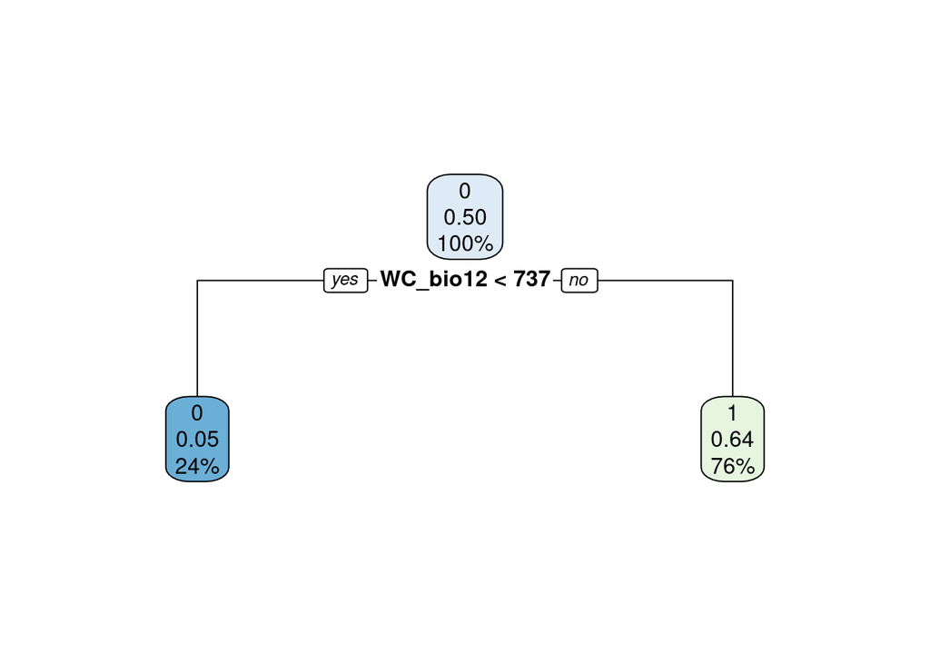

```r
par(mar = c(1, 1, 1, 1))
rpart.plot(mod)
```

## 3.3 Partition, depth = default

- run decision tree model with default settings
- plot the decision tree
- plot the complexity parameter
- display the cross validation results

```r
mod <- rpart(present ~ ., data = d_train)
mod
```

```
## n= 1237
##
## node), split, n, loss, yval, (yprob)
##       * denotes terminal node
##
##   1) root 1237 617 0 (0.50121261 0.49878739)
##     2) WC_bio12< 736.5 297  15 0 (0.94949495 0.05050505) *
##     3) WC_bio12>=736.5 940 338 1 (0.35957447 0.64042553)
##       6) WC_bio1>=11.95 204  67 0 (0.67156863 0.32843137)
##        12) lon>=-94.50892 156  34 0 (0.78205128 0.21794872) *
##        13) lon< -94.50892 48  15 1 (0.31250000 0.68750000)
##          26) lon< -95.68893 21   7 0 (0.66666667 0.33333333) *
##          27) lon>=-95.68893 27   1 1 (0.03703704 0.96296296) *
##       7) WC_bio1< 11.95 736 201 1 (0.27309783 0.72690217)
##        14) WC_bio1< 2.8 48   3 0 (0.93750000 0.06250000) *
##        15) WC_bio1>=2.8 688 156 1 (0.22674419 0.77325581)
##          30) lon< -85.69593 127  63 1 (0.49606299 0.50393701)
##            60) lon< -93.35026 11   0 0 (1.00000000 0.00000000) *
##            61) lon>=-93.35026 116  52 1 (0.44827586 0.55172414)
##             122) ER_topoWet< 14.52 108  52 1 (0.48148148 0.51851852)
##               244) WC_bio4< 104.01 57  22 0 (0.61403509 0.38596491) *
##               245) WC_bio4>=104.01 51  17 1 (0.33333333 0.66666667) *
##             123) ER_topoWet>=14.52 8   0 1 (0.00000000 1.00000000) *
##          31) lon>=-85.69593 561  93 1 (0.16577540 0.83422460)
##            62) WC_alt>=292.5 115  45 1 (0.39130435 0.60869565)
##             124) lon>=-75.31496 15   0 0 (1.00000000 0.00000000) *
##             125) lon< -75.31496 100  30 1 (0.30000000 0.70000000)
##               250) WC_bio1>=9.35 23   8 0 (0.65217391 0.34782609) *
##               251) WC_bio1< 9.35 77  15 1 (0.19480519 0.80519481) *
##            63) WC_alt< 292.5 446  48 1 (0.10762332 0.89237668) *
```

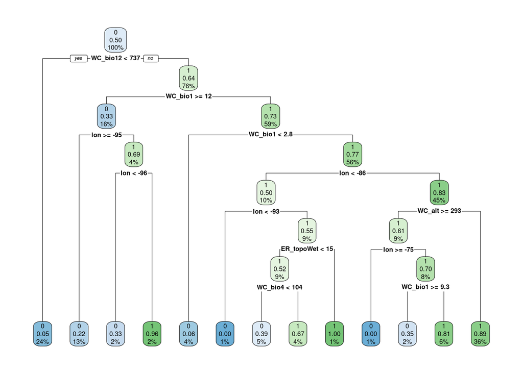

```r
rpart.plot(mod)
```

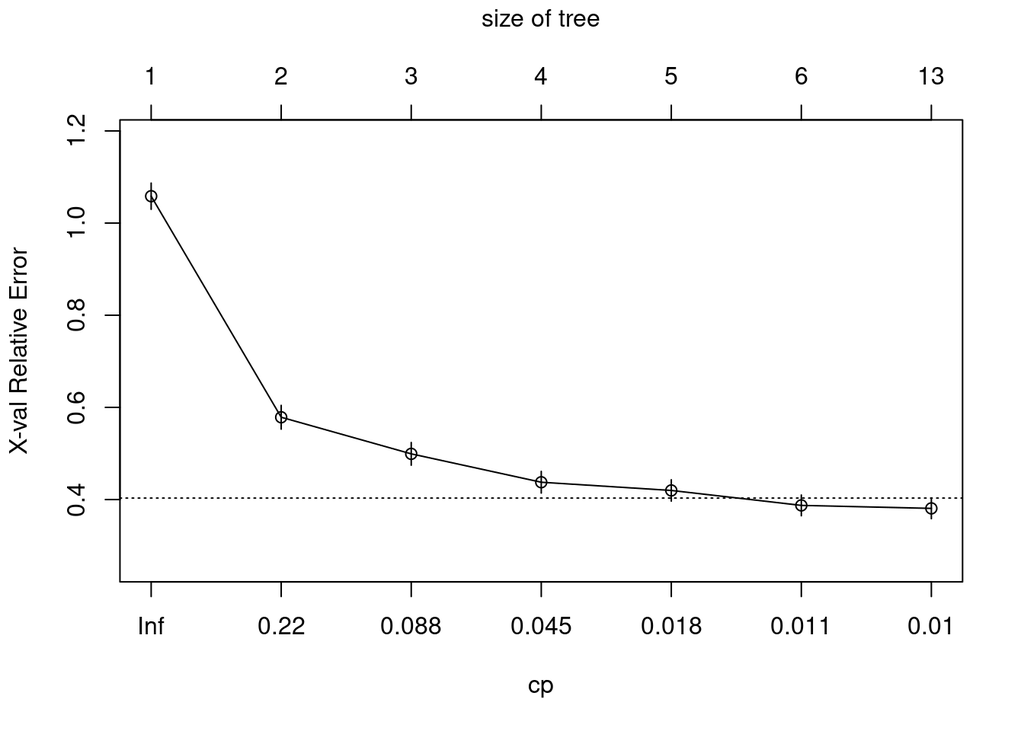

```r
# plot complexity parameter
plotcp(mod)
```

```r
# rpart cross validation results
mod$cptable
```

```
##           CP nsplit rel error    xerror       xstd
## 1 0.42787682      0 1.0000000 1.0583468 0.02845725
## 2 0.11345219      1 0.5721232 0.5786062 0.02582887
## 3 0.06807131      2 0.4586710 0.4991896 0.02464979
## 4 0.02917342      3 0.3905997 0.4376013 0.02354643
## 5 0.01134522      4 0.3614263 0.4197731 0.02319259
## 6 0.01053485      5 0.3500810 0.3873582 0.02250579
## 7 0.01000000     12 0.2755267 0.3808752 0.02236134
```

## 3.4 Feature Interpretation

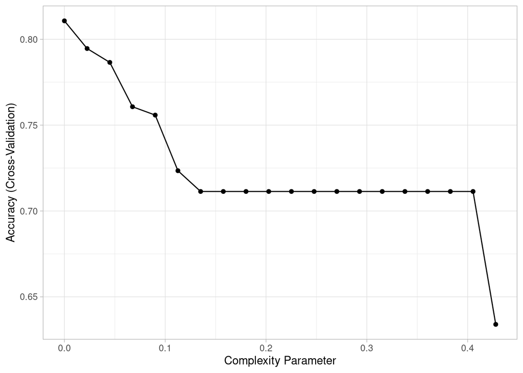

```r
mdl_caret <- train(
  present ~ .,
  data       = d_train,
  method     = "rpart",
  trControl  = trainControl(method = "cv", number = 10),
  tuneLength = 20)

ggplot(mdl_caret)
```

## 3.5 Examine the importance of each predictor

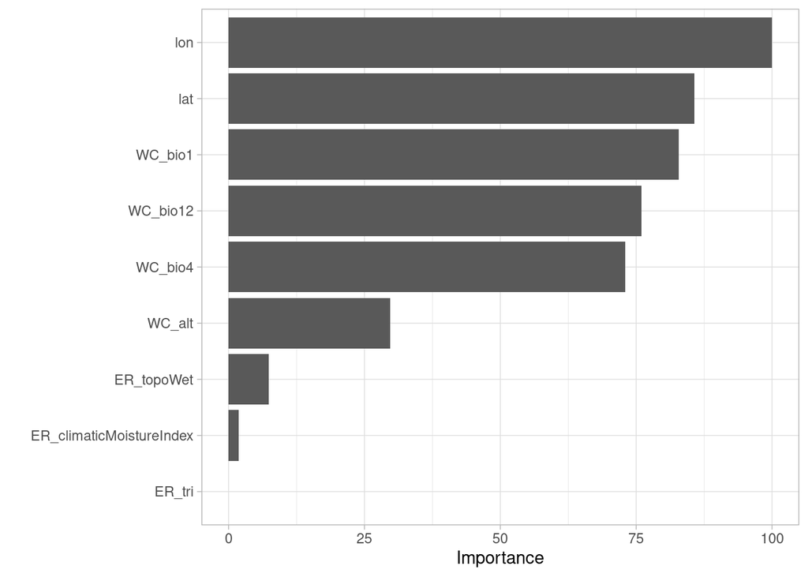

```r
vip(mdl_caret, num_features = 40, bar = FALSE)
```

# 4 Partial dependence plots

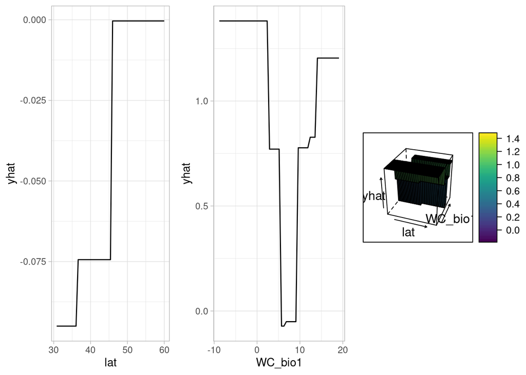

```r
p1 <- partial(mdl_caret, pred.var = "lat") %>% autoplot()
p2 <- partial(mdl_caret, pred.var = "WC_bio1") %>% autoplot()
p3 <- partial(mdl_caret, pred.var = c("lat", "WC_bio1")) %>%
  plotPartial(levelplot = FALSE, zlab = "yhat", drape = TRUE,
              colorkey = TRUE, screen = list(z = -20, x = -60))

gridExtra::grid.arrange(p1, p2, p3, ncol = 3)
```